# Hello World of R Wonders

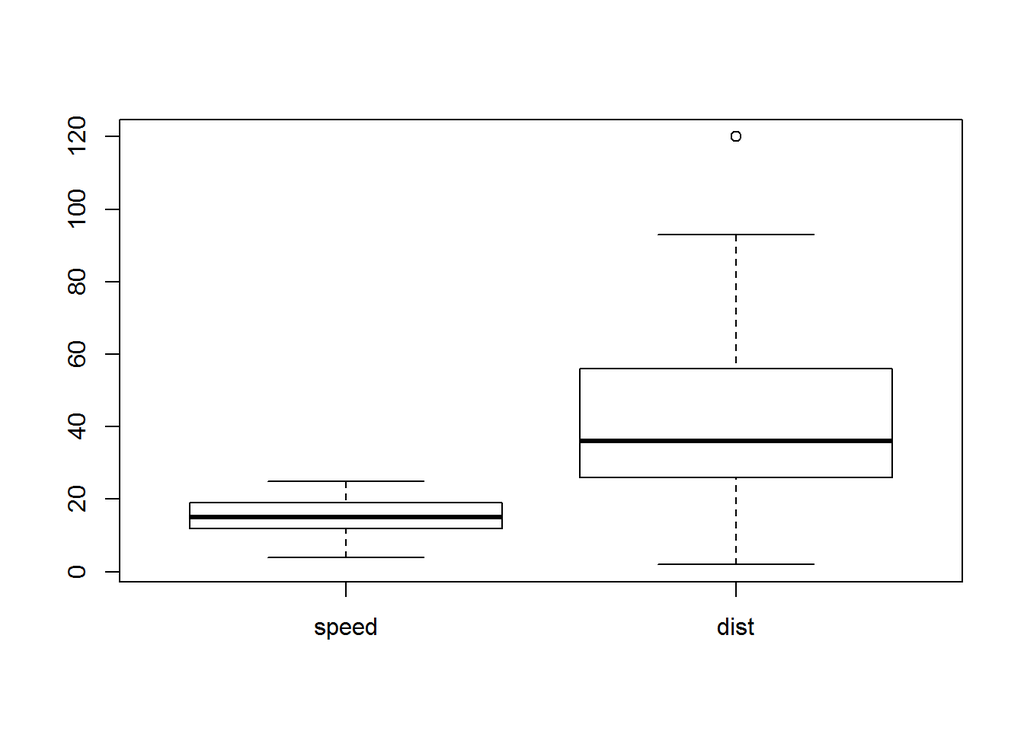

```r
boxplot(cars)
```

## Capacitação prévia em R

Abaixo os códigos para visualização das colunas de cada uma dos dataframes já trabalhados até aqui. Para incluir códigos no RMarkdown basta incluir uma linha de código R começando com os caracteres ```{r} ou pressionar o botão insert e escolher R.

```r
#Os comentários em R começam com esse símbolo#
cars$speed #acessando os valores da coluna speed do dataframe cars
```

```
##  [1]  4  4  7  7  8  9 10 10 10 11 11 12 12 12 12 13 13 13 13 14 14 14 14
## [24] 15 15 15 16 16 17 17 17 18 18 18 18 19 19 19 20 20 20 20 20 22 23 24
## [47] 24 24 24 25
```

```r
cars$dist #acessando os valores da coluna dist do cataframe cars
```

```
##  [1]   2  10   4  22  16  10  18  26  34  17  28  14  20  24  28  26  34
## [18]  34  46  26  36  60  80  20  26  54  32  40  32  40  50  42  56  76
## [35]  84  36  46  68  32  48  52  56  64  66  54  70  92  93 120  85
```

```r
pressure$temperature #acessando os valores da colna temperature do dataframe pressure
```

```
##  [1]   0  20  40  60  80 100 120 140 160 180 200 220 240 260 280 300 320
## [18] 340 360
```

```r
pressure$pressure #acessando os valores da colna temperature do dataframe pressure
```

```
##  [1]   0.0002   0.0012   0.0060   0.0300   0.0900   0.2700   0.7500
##  [8]   1.8500   4.2000   8.8000  17.3000  32.1000  57.0000  96.0000
## [15] 157.0000 247.0000 376.0000 558.0000 806.0000
```

Pela facilidade de manipulação de dados, o dataframe e o seu irmão tibble são portanto os principais objetos a serem trabalhados quando se usa análise de dados em R.

# Engenharia reversa do Ressignficando o RTN

Vamos agora à replicação de alguns elementos presentes na aplicação Resssignificando o RTN.

Para isso serão trabalhados os seguintes tópicos:

- atribuição de valores

```r
ultima_carga<-"" #atribuição de string vazia a uma variável. Comando de atribuição é o <-
```

- consumo de dados previamente trabalhados

```r
load("todas_series.Rdata") #carrega todos os objetos que estão no arquivo Rdata
```

- consumo de dados de api

```r
library(ckanr)
tb_ckan<-resource_show(id="527ccdb1-3059-42f3-bf23-b5e3ab4c6dc6",url="http://apickan.tesouro.gov.br/ckan") #consumo de dados da api do Ckan que contém os dados do tesouro transparente

fab<-resource_show(id="527ccdb1-3059-42f3-bf23-b5e3ab4c6dc6",url="http://www.tesourotransparente.gov.br/ckan") #consumo de dados da api do Ckan que contém os dados do tesouro transparente
```

- objeto tipo lista

```r
mudou<- (tb_ckan$last_modified!=ultima_carga)
```

- teste lógico
- manipuação de string (gsub e paste)

[- sugestão para explorar autonomamente a biblioteca string r](https://cran.r-project.org/web/packages/stringr/vignettes/stringr.html)

- manipulação de arquivos
- leitura de arquivo xlsx
- nomes de colunas em dataframe
- funções gather e split
- conversão de tipos (as.numeri, as.Date)
- Função gather/split

```r
library(readxl)
#library(XLConnect)
#library(tidyr)
#library(RCurl)

if (mudou){ #teste lógico
  ultima_carga<- tb_ckan$last_modified
  URL_add <- tb_ckan$url

  URL_add<-gsub("https://www.tesourotransparente.gov.br","https://apickan.tesouro.gov.br",URL_add) #substituição de strings

  tmp = paste(getwd(),"temp.xlsx") #concatenação de strings

  #extra: verificar também substring
  #extra: explorar também a biblioteca stringr


  tmp = tempfile(fileext = ".xlsx") #cria um arquivo temporário em uma pasta temporária no formato xlsx


  download.file(URL_add,mode = "wb", destfile = tmp) #função para download de arquivo

  #############Verificar comentário abaixo imporante
  #rtn_geral <- read.xlsx(tmp, sheetIndex=2, rowIndex = c(5:79)) #não usar essa função por estara associada a uma bibiloteca com dependência do java

  rtn_geral <- read_xlsx(tmp,sheet = 2,skip = 4,n_max = 74)
  # a função read_xlsx permite várias combinações de parâmetro para utilizar somente os dados que interessam
  #observar que o resultado da função já é um dataframe

  rtn_receita<- read_xlsx(tmp,sheet = 4,skip = 4,n_max = 48)
  rtn_despesa<- read_xlsx(tmp,sheet = 8,skip = 4,n_max = 88)

  deflator_IPCA <- read_xlsx(tmp,sheet = 5,skip = 54,n_max = 1, col_names = FALSE) #observar nesse caso que não se utilizou a primeira linha da tabela como nome de coluna

  names(deflator_IPCA)<-names(rtn_receita) #identificação e alteração do nome das colunas de um datafrme



  names(rtn_geral)[1]<-"Rubrica" #alteração de apenas um nome de coluna. Aqui se percebe como se trabalha com vetores

  series_temporais_analise<-gather(rtn_geral,Data, Valor,-Rubrica) #função para pivotar um data.frame é simétrico ao split

  #series_temporais_analise$Data<-gsub("X","",series_temporais_analise$Data)

  series_temporais_analise$Data<-as.Date(as.numeric(series_temporais_analise$Data), origin="1899-12-30") #faz duas conversões de tipos. primeiro de string para numérico e depois de numérico para data. O argumento origem indica a partir de que data deve-se contar o número de dias que o valor convertido faz referência

  series_temporais_analise$Valor <-as.numeric(series_temporais_analise$Valor)


  series_temporais_analise$Valor[is.na(series_temporais_analise$Valor)]<-0 #is.na procura valores de dataframe que não estão povoados (missings no vocabulário da estatística)

  rm(rtn_geral) #remove objeto da memória
}
```

- Manipulação de vetores e dataframes
- Filtro usando notação RBase
- Visualização de gráficos para verificação do efeito do filtro (trabalhando com arquivo de script diferente para testes)

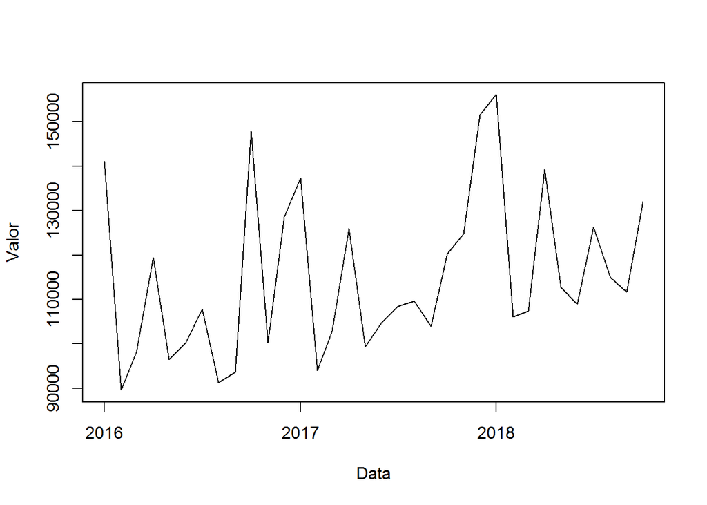

```r
rubrica<- "I. RECEITA TOTAL"
ano <- c("2016","2017","2018")
df_plot<- series_temporais_analise[series_temporais_analise$Rubrica == rubrica & substr(series_temporais_analise$Data,1,4)%in%ano ,c(2,3)] #filtro usando duas condições

plot(df_plot, type="l") #plotar um gráfico simples usando os recursos do RBase
```